## Setup

### Load packages

```r
library(ggplot2)
library(dplyr)
library(statsr)
library(BAS)
library(grid)
library(gridExtra)
library(MASS)
library(GGally)
```

### Load data

```r
load("movies.Rdata")
```

## Part 1: Data

The data comprised of 651 randomly sampled movies produced and released before 2016. It is randomly sampled, but not randomly assigned. Therefore, the data should allow us to generalize to the population of interest. But we cannot establish a caual connection between variables, but only an association. Since the voting and rating are voluntary on IMDB and Rotten Tomatos website, we should be concerned about the voluntary response bias, which occurs when the sample consists of people who volunteer to respond because they have strong opinions on the issue.

## Part 2: Data manipulation

1. Create the new variable ‘feature_film’

```r
movies<-movies%>%mutate(feature_film = ifelse(title_type == "Feature Film", "yes", "no"))
```

2. Create the new variable ‘drama’

```r
movies<-movies%>%mutate(drama = ifelse(genre == "Drama", "yes", "no"))
```

3. Create the new variable ‘mpaa_rating_R’

```r
movies<-movies%>%mutate(mpaa_rating_R = ifelse(mpaa_rating == "R", "yes", "no"))
```

4. Create the two new variables ‘oscar_season’ and ‘summer_season’

```r
movies<-movies%>%mutate(oscar_season = ifelse(thtr_rel_month=="11"|thtr_rel_month=="12"|thtr_rel_month=="1","yes","no"))
```

```r
movies<-movies%>%mutate(summer_season = ifelse(thtr_rel_month %in% c(5,6,7,8),"yes","no"))
```

## Part 3: Exploratory data analysis

Let’s first look at the summary and distribution of the ‘audience_score’ variable.

```r
summary(movies$audience_score)
```

```
##    Min. 1st Qu.  Median    Mean 3rd Qu.    Max.
##   11.00   46.00   65.00   62.36   80.00   97.00
```

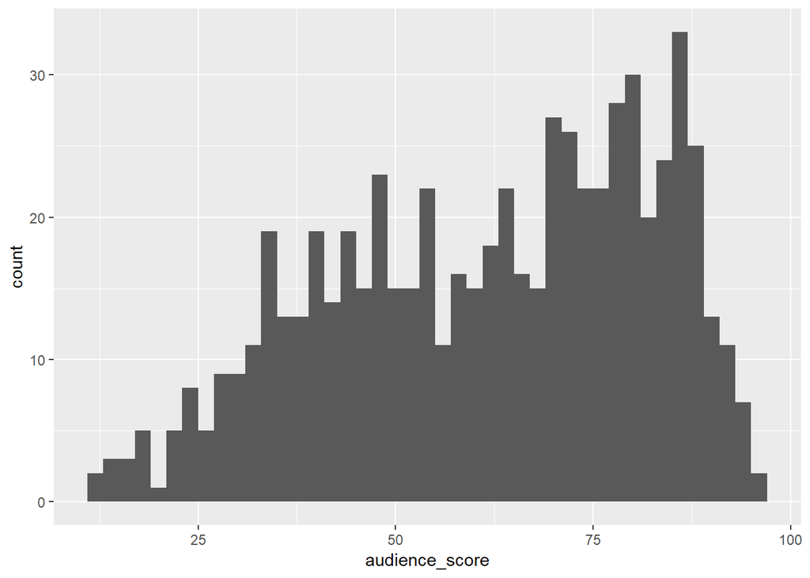

```r
ggplot(movies)+geom_histogram(mapping = aes(x=audience_score),binwidth = 2)
```

The distribution shows a left skew, with its mean about 3 points lower than the median.

Let’s look at the distributions of the new variables, using bar charts.

```r
bar1<-ggplot(movies)+geom_bar(mapping = aes(x=feature_film))+coord_flip()+ ggtitle('Feature Film')

bar2<-ggplot(movies)+geom_bar(mapping = aes(x=drama))+coord_flip()+ggtitle('Drama')
bar3<-ggplot(movies)+geom_bar(mapping = aes(x=mpaa_rating_R))+coord_flip()+ggtitle('Mpaa_rating_R')
bar4<-ggplot(movies)+geom_bar(mapping = aes(x=oscar_season))+coord_flip()+ggtitle('Oscar_season')
bar5<-ggplot(movies)+geom_bar(mapping = aes(x=summer_season))+coord_flip()+ggtitle('Summer_season')
```

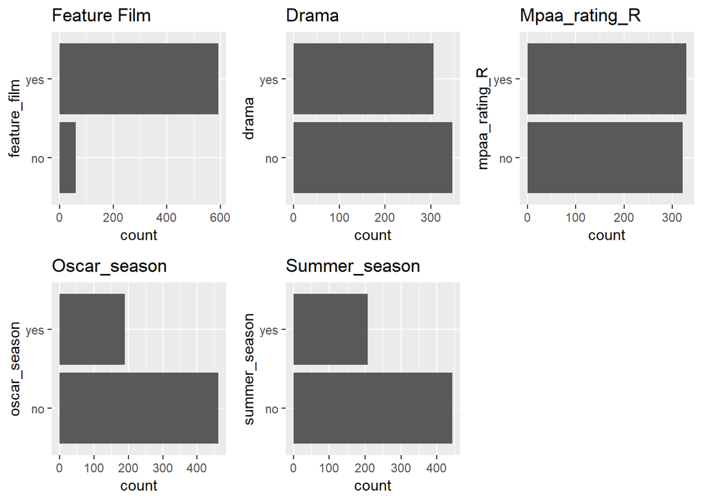

```r
grid.arrange(bar1,bar2,bar3,bar4,bar5,ncol=3)
```

Let’s look at the distribution of ‘audience_score’ by the new variables using summary statisitcs and boxplots.

```r
movies%>%group_by(feature_film)%>%summarise(n=n(),scoremean=mean(audience_score),scoremedian=median(audience_score),scoresd=sd(audience_score),scoremin=min(audience_score),scoremax=max(audience_score))%>%mutate(rel.freq=paste0(round(100*n/sum(n),2),"%"))
```

```
## # A tibble: 2 x 8
##   feature_film     n scoremean scoremedian scoresd scoremin scoremax
##   <chr>        <int>     <dbl>       <dbl>   <dbl>    <dbl>    <dbl>
## 1 no              60      81.0        85.5    13.6       19       96
## 2 yes            591      60.5        62      19.8       11       97
## # ... with 1 more variable: rel.freq <chr>
```

```r
movies%>%group_by(drama)%>%summarise(n=n(),scoremean=mean(audience_score),scoremedian=median(audience_score),scoresd=sd(audience_score),scoremin=min(audience_score),scoremax=max(audience_score))%>%mutate(rel.freq=paste0(round(100*n/sum(n),2),"%"))
```

```
## # A tibble: 2 x 8
##   drama     n scoremean scoremedian scoresd scoremin scoremax rel.freq
##   <chr> <int>     <dbl>       <dbl>   <dbl>    <dbl>    <dbl> <chr>
## 1 no      346      59.7          61    21.3       11       97 53.15%
## 2 yes     305      65.3          70    18.5       13       95 46.85%
```

```r
movies%>%group_by(mpaa_rating_R)%>%summarise(n=n(),scoremean=mean(audience_score),scoremedian=median(audience_score),scoresd=sd(audience_score),scoremin=min(audience_score),scoremax=max(audience_score))%>%mutate(rel.freq=paste0(round(100*n/sum(n),2),"%"))
```

```
## # A tibble: 2 x 8
##   mpaa_rating_R     n scoremean scoremedian scoresd scoremin scoremax
##   <chr>         <int>     <dbl>       <dbl>   <dbl>    <dbl>    <dbl>
## 1 no              322      62.7        65.5    20.3       11       96
## 2 yes             329      62.0        64      20.2       14       97
## # ... with 1 more variable: rel.freq <chr>
```

```r
movies%>%group_by(oscar_season)%>%summarise(n=n(),scoremean=mean(audience_score),scoremedian=median(audience_score),scoresd=sd(audience_score),scoremin=min(audience_score),scoremax=max(audience_score))%>%mutate(rel.freq=paste0(round(100*n/sum(n),2),"%"))
```

```
## # A tibble: 2 x 8
##   oscar_season     n scoremean scoremedian scoresd scoremin scoremax
##   <chr>        <int>     <dbl>       <dbl>   <dbl>    <dbl>    <dbl>
## 1 no             461      61.7          65    20.5       11       96
## 2 yes            190      64.0          67    19.6       17       97
## # ... with 1 more variable: rel.freq <chr>
```

```r
movies%>%group_by(summer_season)%>%summarise(n=n(),scoremean=mean(audience_score),scoremedian=median(audience_score),scoresd=sd(audience_score),scoremin=min(audience_score),scoremax=max(audience_score))%>%mutate(rel.freq=paste0(round(100*n/sum(n),2),"%"))
```

```
## # A tibble: 2 x 8
##   summer_season     n scoremean scoremedian scoresd scoremin scoremax
##   <chr>         <int>     <dbl>       <dbl>   <dbl>    <dbl>    <dbl>
## 1 no              443      62.6          66    20.4       13       97
## 2 yes             208      61.8          65    19.9       11       94
## # ... with 1 more variable: rel.freq <chr>
```

```r
box1<-ggplot(data=movies,mapping = aes(x=feature_film,y=audience_score))+geom_boxplot()
box2<-ggplot(data=movies,mapping = aes(x=drama,y=audience_score))+geom_boxplot()
box3<-ggplot(data=movies,mapping = aes(x=mpaa_rating_R,y=audience_score))+geom_boxplot()
box4<-ggplot(data=movies,mapping = aes(x=oscar_season,y=audience_score))+geom_boxplot()
box5<-ggplot(data=movies,mapping = aes(x=summer_season,y=audience_score))+geom_boxplot()
```

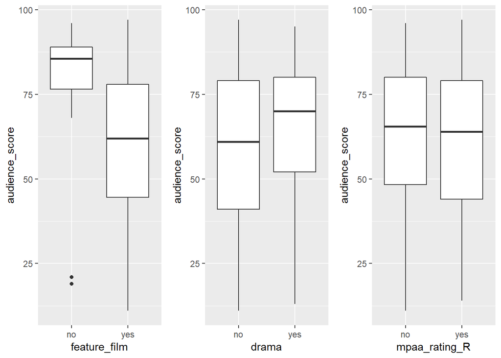

```r
grid.arrange(box1,box2,box3,ncol=3)
```

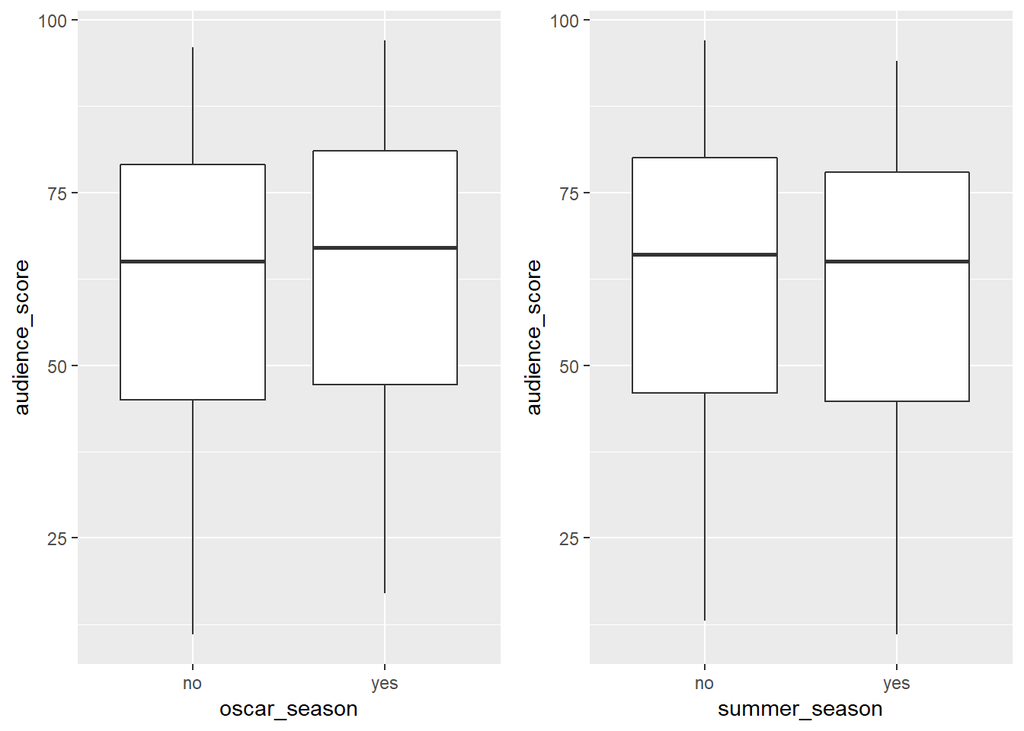

```r
grid.arrange(box4,box5,ncol=2)
```

We can find that movies that aren’t feature type, mostly documentaries, have strikingly higher audience scores than feature films. However, their proportion is just 9.22% of all movies in the data. Also, drama movies and movies released in oscar seasons, respectively accounting for 46.85% and 29.19%, have higher audiece scores than other movies. By constrast, movies that are rated ‘R’ and movies released in summer seasons, which account for 50.54% and 31.95%, have slightly lower average audience scores than other movies. But the differences are just less than 1 score point for both of them.

We can also visualize the relationship between the continous variable ‘audience_score’ and the new variables, which all are categorical variables, using geom_freqpoly.

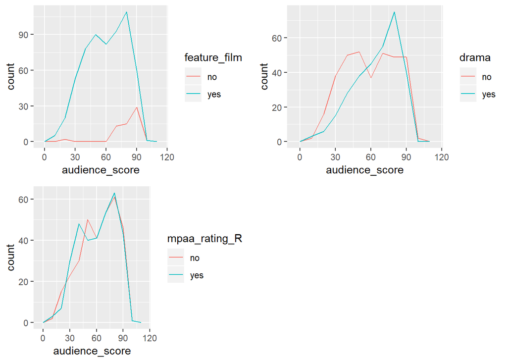

```r
freqpoly1<-ggplot(data=movies,mapping = aes(x=audience_score))+geom_freqpoly(mapping=aes(color=feature_film),binwidth=10)

freqpoly2<-ggplot(data=movies,mapping = aes(x=audience_score))+geom_freqpoly(mapping=aes(color=drama),binwidth=10)

freqpoly3<-ggplot(data=movies,mapping = aes(x=audience_score))+geom_freqpoly(mapping=aes(color=mpaa_rating_R),binwidth=10)

freqpoly4<-ggplot(data=movies,mapping = aes(x=audience_score))+geom_freqpoly(mapping=aes(color=oscar_season),binwidth=10)

freqpoly5<-ggplot(data=movies,mapping = aes(x=audience_score))+geom_freqpoly(mapping = aes(color=summer_season),binwidth=10)


grid.arrange(freqpoly1,freqpoly2,freqpoly3,ncol=2)
```

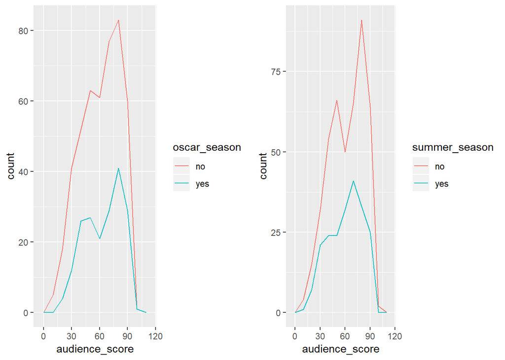

```r
grid.arrange(freqpoly4,freqpoly5,ncol=2)
```

Because the overall counts differ so much by each variable, it’s hard to compare the distributions. Instead of displaying count on the y-axis, we can display density on the y-axis so that the area under each frequency polygon is one.

```r
freqpoly1d<-ggplot(data=movies,mapping = aes(x=audience_score,y=..density..))+geom_freqpoly(mapping=aes(color=feature_film),binwidth=10)

freqpoly2d<-ggplot(data=movies,mapping = aes(x=audience_score,y=..density..))+geom_freqpoly(mapping=aes(color=drama),binwidth=10)

freqpoly3d<-ggplot(data=movies,mapping = aes(x=audience_score,y=..density..))+geom_freqpoly(mapping=aes(color=mpaa_rating_R),binwidth=10)
```

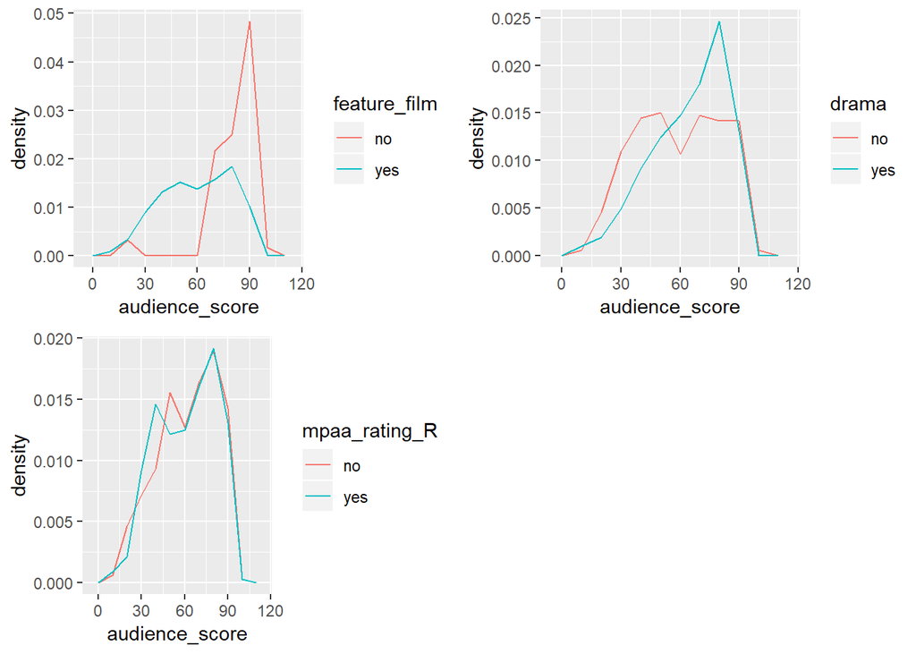

```r
grid.arrange(freqpoly1d,freqpoly2d,freqpoly3d,ncol=2)
```

```r
freqpoly4d<-ggplot(data=movies,mapping = aes(x=audience_score,y=..density..))+geom_freqpoly(mapping=aes(color=oscar_season),binwidth=10)

freqpoly5d<-ggplot(data=movies,mapping = aes(x=audience_score,y=..density..))+geom_freqpoly(mapping = aes(color=summer_season),binwidth=10)
```

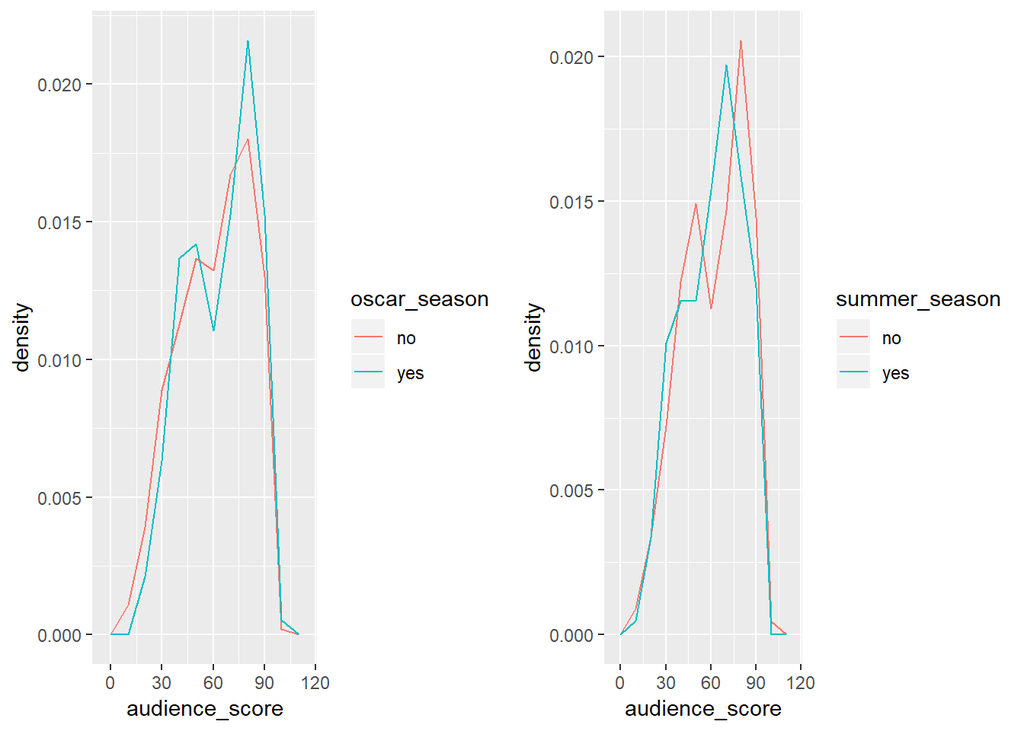

```r
grid.arrange(freqpoly4d,freqpoly5d,ncol=2)
```

## Part 4: Modeling

Variables to consider for the full model

the response variable: audience_score

the explanatory variables:

feature_film,drama,runtime,mpaa_rating_R,thtr_rel_year,oscar_season,summer_season,imdb_rating,imdb_num_votes,critics_score,best_pic_nom,best_pic_win,best_actor_win,best_actress_win,best_dir_win,top200_box

```r
#fitting the initial full model

aud_score.mlr<-lm(audience_score ~ feature_film+drama+runtime+mpaa_rating_R+
thtr_rel_year+oscar_season+summer_season+imdb_rating+imdb_num_votes+critics_score+best_pic_nom+best_pic_win+best_actor_win+best_actress_win+best_dir_win+top200_box , data = movies)
```

Bayesian model selection criteria to consider : BIC, pick model with the highest posterior probability, pick the best predictive model

Since the project rubric requires students to report the final model and interpret the model coefficients, I’ve decided to choose a single model instead of using Bayesian model averaging.

There are several Bayesian Model selection criteria introduced in the lecture. “BIC is one of the Bayeian criteria, and tends to be one the most popular criteria. When using BIC to select a model, it’s common to report parameter estimates based on the reference prior. The estimates under the reference posterior distribution can be obtained using the OLS estimates from R. BIC tends to select parsimonious models while AIC and adjusted r squared may include terms that are not statistically significant, however, may do better for prediction. Other approaches to Bayesian model selection can be based on selecting a model with the highest posterior probability. Or, if our objective is prediction from a single model, the best choice is to find the model whose predictions are closest to those given by BMA. Using the squared error loss, we find that the best predictive model is the one whose predictions are closest to BMA”.

Firstly, let’s select the model using BIC.

```r
# perform stepwise selection according to BIC (in which case k = log(n) where
# n is the number of observations)

stepAIC(aud_score.mlr, k=log(651))
```

```
## Start:  AIC=3083.01
## audience_score ~ feature_film + drama + runtime + mpaa_rating_R +
##     thtr_rel_year + oscar_season + summer_season + imdb_rating +
##     imdb_num_votes + critics_score + best_pic_nom + best_pic_win +
##     best_actor_win + best_actress_win + best_dir_win + top200_box
##
##                    Df Sum of Sq    RSS    AIC
## - top200_box        1         5  62988 3076.6
## - oscar_season      1        35  63018 3076.9
## - best_pic_win      1        46  63029 3077.0
## - best_dir_win      1        54  63037 3077.1
## - best_actor_win    1       173  63156 3078.3
## - feature_film      1       184  63167 3078.4
## - summer_season     1       210  63193 3078.7
## - drama             1       223  63206 3078.8
## - imdb_num_votes    1       260  63243 3079.2
## - best_actress_win  1       280  63263 3079.4
## - mpaa_rating_R     1       307  63290 3079.7
## - thtr_rel_year     1       363  63346 3080.3
## - best_pic_nom      1       376  63359 3080.4
## - runtime           1       615  63598 3082.8
## <none>                           62983 3083.0
## - critics_score     1       670  63653 3083.4
## - imdb_rating       1     58549 121532 3503.8
##
## Step:  AIC=3076.58
## audience_score ~ feature_film + drama + runtime + mpaa_rating_R +
##     thtr_rel_year + oscar_season + summer_season + imdb_rating +
##     imdb_num_votes + critics_score + best_pic_nom + best_pic_win +
##     best_actor_win + best_actress_win + best_dir_win
##
##                    Df Sum of Sq    RSS    AIC
## - oscar_season      1        37  63025 3070.5
## - best_pic_win      1        47  63035 3070.6
## - best_dir_win      1        55  63043 3070.7
## - best_actor_win    1       172  63160 3071.9
## - feature_film      1       183  63171 3072.0
## - summer_season     1       214  63202 3072.3
## - drama             1       221  63209 3072.4
## - best_actress_win  1       277  63265 3073.0
```

[output cut: 185 more lines]

```
##                 Df Sum of Sq    RSS    AIC
## - mpaa_rating_R  1       361  65126 3020.5
## - runtime        1       638  65403 3023.3
## <none>                        64765 3023.4
## - critics_score  1      1027  65792 3027.1
## - imdb_rating    1     68173 132937 3484.3
##
## Step:  AIC=3020.53
## audience_score ~ runtime + imdb_rating + critics_score
##
##                 Df Sum of Sq    RSS    AIC
## <none>                        65126 3020.5
## - runtime        1       653  65779 3020.5
## - critics_score  1      1073  66199 3024.7
## - imdb_rating    1     67874 133000 3478.2
```

```
##
## Call:
## lm(formula = audience_score ~ runtime + imdb_rating + critics_score,
##     data = movies)
##
## Coefficients:
##   (Intercept)        runtime    imdb_rating  critics_score
##     -33.28321       -0.05362       14.98076        0.07036
```

The best model according to BIC comes out to be lm(formula = audience_score ~ runtime + imdb_rating + critics_score, data = movies)

Let’s compare that with the highest probaibility model and the best predictive model under BMA

To do that, we first do Bayesian model averaging.

```r
#Bayesian model averaging using prior = "BIC"

audscore.BIC <- bas.lm(audience_score ~ feature_film+drama+runtime+mpaa_rating_R+
thtr_rel_year+oscar_season+summer_season+imdb_rating+imdb_num_votes+critics_score+best_pic_nom+best_pic_win+best_actor_win+best_actress_win+best_dir_win+top200_box , data = movies,  prior = "BIC",modelprior = uniform())
```

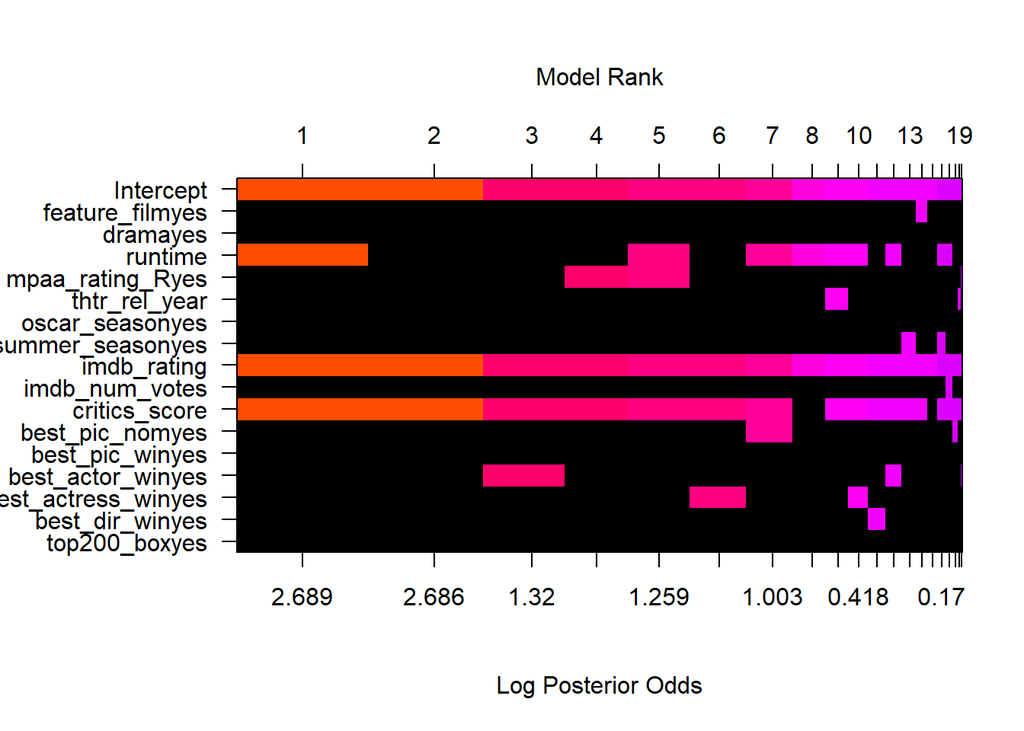

```r
image(audscore.BIC, rotate=FALSE)
```

```r
summary(audscore.BIC)
```

```
##                     P(B != 0 | Y)    model 1       model 2       model 3
## Intercept              1.00000000     1.0000     1.0000000     1.0000000
## feature_filmyes        0.06533412     0.0000     0.0000000     0.0000000
## dramayes               0.04328167     0.0000     0.0000000     0.0000000
## runtime                0.47956121     1.0000     0.0000000     0.0000000
## mpaa_rating_Ryes       0.19964741     0.0000     0.0000000     0.0000000
## thtr_rel_year          0.09038659     0.0000     0.0000000     0.0000000
## oscar_seasonyes        0.04013208     0.0000     0.0000000     0.0000000
## summer_seasonyes       0.08372559     0.0000     0.0000000     0.0000000
## imdb_rating            1.00000000     1.0000     1.0000000     1.0000000
## imdb_num_votes         0.05798924     0.0000     0.0000000     0.0000000
## critics_score          0.88910903     1.0000     1.0000000     1.0000000
## best_pic_nomyes        0.12955968     0.0000     0.0000000     0.0000000
## best_pic_winyes        0.03982216     0.0000     0.0000000     0.0000000
## best_actor_winyes      0.14531595     0.0000     0.0000000     1.0000000
## best_actress_winyes    0.14129961     0.0000     0.0000000     0.0000000
## best_dir_winyes        0.06703461     0.0000     0.0000000     0.0000000
## top200_boxyes          0.04750177     0.0000     0.0000000     0.0000000
## BF                             NA     1.0000     0.9968489     0.2543185
## PostProbs                      NA     0.1346     0.1341000     0.0342000
## R2                             NA     0.7549     0.7525000     0.7539000
## dim                            NA     4.0000     3.0000000     4.0000000
## logmarg                        NA -3615.2791 -3615.2822108 -3616.6482224
##                           model 4       model 5
## Intercept               1.0000000     1.0000000
## feature_filmyes         0.0000000     0.0000000
## dramayes                0.0000000     0.0000000
## runtime                 0.0000000     1.0000000
## mpaa_rating_Ryes        1.0000000     1.0000000
## thtr_rel_year           0.0000000     0.0000000
## oscar_seasonyes         0.0000000     0.0000000
## summer_seasonyes        0.0000000     0.0000000
## imdb_rating             1.0000000     1.0000000
## imdb_num_votes          0.0000000     0.0000000
## critics_score           1.0000000     1.0000000
## best_pic_nomyes         0.0000000     0.0000000
## best_pic_winyes         0.0000000     0.0000000
## best_actor_winyes       0.0000000     0.0000000
## best_actress_winyes     0.0000000     0.0000000
## best_dir_winyes         0.0000000     0.0000000
## top200_boxyes           0.0000000     0.0000000
## BF                      0.2521327     0.2391994
## PostProbs               0.0339000     0.0322000
## R2                      0.7539000     0.7563000
## dim                     4.0000000     5.0000000
## logmarg             -3616.6568544 -3616.7095127
```

The model with the highest posterior probability has a posterior probability of 13.46 % and has the same three predictors as the model selected according to BIC. But the second highest probability model also has a similar 13.41 % and it doesn’t include the variable ‘runtime’. The posterior inclusion probabilities of three variables runtime,imdb_rating ,critics_score come out to be 47.95% , 100% , 88. 91 % respectivly.

We can extract the names of predictors in the best probabilty model using below codes.

```r
#Extracting names of predictors of the highest probaibility model under "BIC"
audscore_BIC.HPM = predict(audscore.BIC,estimator = "HPM")
variable.names(audscore_BIC.HPM)
```

```
## [1] "Intercept"     "runtime"       "imdb_rating"   "critics_score"
```

Let’s extract the names of the predictors in the best prective model.

```r
#Extracting names of predictors of the best predictive model under "BIC"

audscore_BIC.BPM = predict(audscore.BIC,estimator = "BPM")

variable.names(audscore_BIC.BPM)
```

```
## [1] "Intercept"     "runtime"       "imdb_rating"   "critics_score"
```

The best predictive model also has runtime, imdb_rating, critics_score as predictors of audience_score.

Before finalizing the model, I’ve checked results using “ZS-null” instead of “BIC” as priors on model coeffienct. However, The results just slighty change under “ZS-null” prior. The only difference is that under “ZS-null”, the highest probaibility model has only two predictors, “imdb_rating” and “critics_score, leaving out”runtime“. The predictors of the best predictive model remain the same.

```r
#Bayesian model averaging using prior = "ZS-null"

audscore.ZS <- bas.lm(audience_score ~ feature_film+drama+runtime+mpaa_rating_R+
thtr_rel_year+oscar_season+summer_season+imdb_rating+imdb_num_votes+critics_score+best_pic_nom+best_pic_win+best_actor_win+best_actress_win+best_dir_win+top200_box , data = movies,  prior = "ZS-null",modelprior = uniform())
```

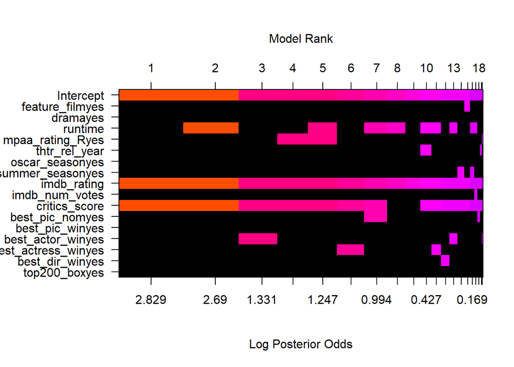

```r
image(audscore.ZS, rotate=FALSE)
```

```r
summary(audscore.ZS)
```

```
##                     P(B != 0 | Y)  model 1     model 2     model 3
## Intercept              1.00000000   1.0000   1.0000000   1.0000000
## feature_filmyes        0.06779088   0.0000   0.0000000   0.0000000
## dramayes               0.04589661   0.0000   0.0000000   0.0000000
## runtime                0.47348067   0.0000   1.0000000   0.0000000
## mpaa_rating_Ryes       0.20214056   0.0000   0.0000000   0.0000000
## thtr_rel_year          0.09440698   0.0000   0.0000000   0.0000000
## oscar_seasonyes        0.04233271   0.0000   0.0000000   0.0000000
## summer_seasonyes       0.08690855   0.0000   0.0000000   0.0000000
## imdb_rating            1.00000000   1.0000   1.0000000   1.0000000
## imdb_num_votes         0.06127399   0.0000   0.0000000   0.0000000
## critics_score          0.88114691   1.0000   1.0000000   1.0000000
## best_pic_nomyes        0.13464893   0.0000   0.0000000   0.0000000
## best_pic_winyes        0.04201392   0.0000   0.0000000   0.0000000
## best_actor_winyes      0.14712455   0.0000   0.0000000   1.0000000
## best_actress_winyes    0.14412736   0.0000   0.0000000   0.0000000
## best_dir_winyes        0.06930639   0.0000   0.0000000   0.0000000
## top200_boxyes          0.04972289   0.0000   0.0000000   0.0000000
## BF                             NA   1.0000   0.8702806   0.2236679
## PostProbs                      NA   0.1441   0.1254000   0.0322000
## R2                             NA   0.7525   0.7549000   0.7539000
## dim                            NA   3.0000   4.0000000   4.0000000
## logmarg                        NA 443.9495 443.8105657 442.4519125
##                         model 4     model 5
## Intercept             1.0000000   1.0000000
## feature_filmyes       0.0000000   0.0000000
## dramayes              0.0000000   0.0000000
## runtime               0.0000000   1.0000000
## mpaa_rating_Ryes      1.0000000   1.0000000
## thtr_rel_year         0.0000000   0.0000000
## oscar_seasonyes       0.0000000   0.0000000
## summer_seasonyes      0.0000000   0.0000000
## imdb_rating           1.0000000   1.0000000
## imdb_num_votes        0.0000000   0.0000000
## critics_score         1.0000000   1.0000000
## best_pic_nomyes       0.0000000   0.0000000
## best_pic_winyes       0.0000000   0.0000000
## best_actor_winyes     0.0000000   0.0000000
## best_actress_winyes   0.0000000   0.0000000
## best_dir_winyes       0.0000000   0.0000000
## top200_boxyes         0.0000000   0.0000000
## BF                    0.2217602   0.2055844
## PostProbs             0.0320000   0.0296000
## R2                    0.7539000   0.7563000
## dim                   4.0000000   5.0000000
## logmarg             442.4433468 442.3676066
```

```r
#Extracting names of predictors of the highest probaibility model under "ZS-null"

audscore_ZS.HPM = predict(audscore.ZS,estimator = "HPM")
variable.names(audscore_ZS.HPM)
```

```
## [1] "Intercept"     "imdb_rating"   "critics_score"
```

```r
#Extracting names of predictors of the best predictive model under "ZS-null"

audscore_ZS.BPM = predict(audscore.ZS,estimator = "BPM")

variable.names(audscore_ZS.BPM)
```

```
## [1] "Intercept"     "runtime"       "imdb_rating"   "critics_score"
```

All in all, it seems reasonable to pick runtime , imdb_rating , critics_score as predictors, when we use bayesian model selection methods

For Bayesian multiple regression, as we have seen, we need to specify a prior distribution for all of the unknown regression coefficients and the unknown variance sigma squared. For our final model, I’m adopting the BIC prior, which is non-informative, reference prior. The reference prior has a uniform, or flat distribution for all of the coefficients in the regression function. We also use the reference prior on sigma squared that is proportional to 1 over sigma squared, or 1 over the variance.

Under the reference prior, point estimates and Bayesian credible intervals are equivalent to frequentist estimates and confidence intervals. We can use standard lm function to obtain them, but there’s change in interpretation.

```r
#fitting the final model and summary

audscore.bayes<-lm(formula = audience_score ~ runtime + imdb_rating + critics_score,
    data = movies)

summary(audscore.bayes)
```

```
##
## Call:
## lm(formula = audience_score ~ runtime + imdb_rating + critics_score,
##     data = movies)
##
## Residuals:
##     Min      1Q  Median      3Q     Max
## -26.998  -6.565   0.557   5.475  52.448
##
## Coefficients:
##                Estimate Std. Error t value Pr(>|t|)
## (Intercept)   -33.28321    3.21939 -10.338  < 2e-16 ***
## runtime        -0.05362    0.02107  -2.545  0.01117 *
## imdb_rating    14.98076    0.57735  25.947  < 2e-16 ***
## critics_score   0.07036    0.02156   3.263  0.00116 **
## ---
## Signif. codes:  0 '***' 0.001 '**' 0.01 '*' 0.05 '.' 0.1 ' ' 1
##
## Residual standard error: 10.04 on 646 degrees of freedom
##   (1 observation deleted due to missingness)
## Multiple R-squared:  0.7549, Adjusted R-squared:  0.7538
## F-statistic: 663.3 on 3 and 646 DF,  p-value: < 2.2e-16
```

BIC tends to select parsimonious models, so it’s no wonder that all three predictors are statistically significant. 75.38% of the variablity in ‘audiece_score’ can be explained by the model.

Let’s turn to model diagnostics

The Bayesian model specification assumes that the errors are normally distributed with a constant variance and that the response variable is linear in numerical variables.

Let’s us start by checking whether each numerical explanatory variable is linearly related to the response variable using residuals plots.

```r
movies<-movies[-c(651),]
```

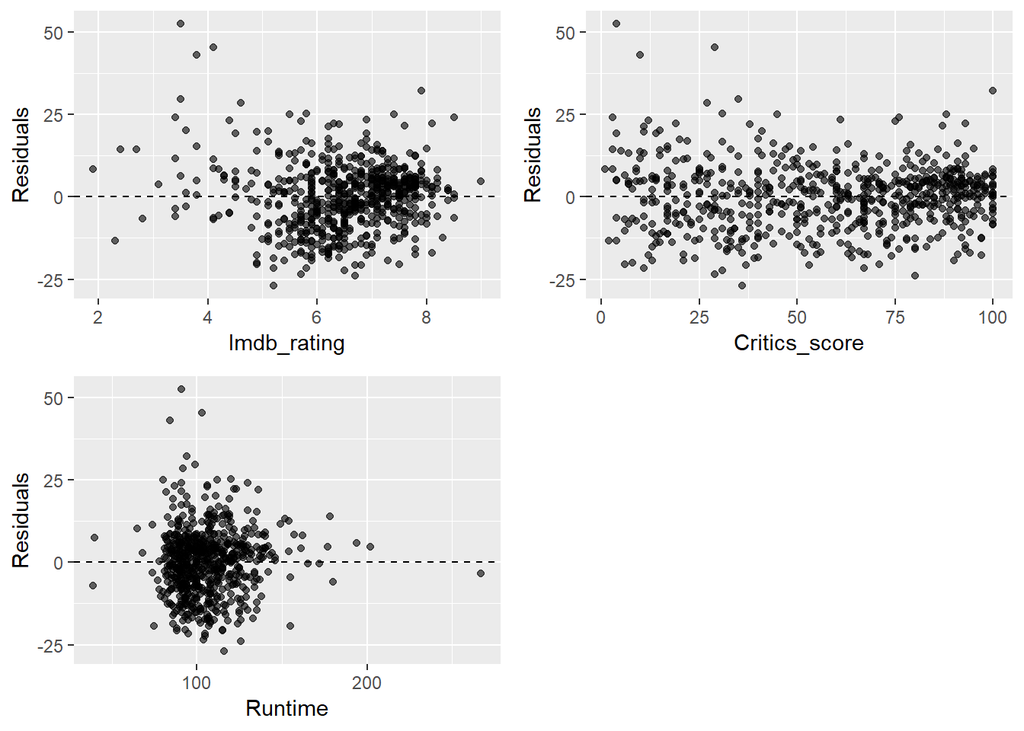

```r
lplot1<-ggplot(data = audscore.bayes, aes(x = movies$imdb_rating, y =.resid )) +
  geom_point(alpha = 0.6) +
  geom_hline(yintercept = 0, linetype = "dashed") +
  labs(x = "Imdb_rating", y = "Residuals")

lplot2<-ggplot(data = audscore.bayes, aes(x = movies$critics_score, y =.resid )) +
  geom_point(alpha = 0.6) +
  geom_hline(yintercept = 0, linetype = "dashed") +
  labs(x = "Critics_score", y = "Residuals")

lplot3<-ggplot(data = audscore.bayes, aes(x = movies$runtime, y =.resid )) +
  geom_point(alpha = 0.6) +
  geom_hline(yintercept = 0, linetype = "dashed") +
  labs(x = "Runtime", y = "Residuals")

grid.arrange(lplot1,lplot2,lplot3, ncol=2)
```

We can see almost random scatter of residuals around 0, so we can assume linear relationships between explanatory variables and the response variable.

Normality: To check this condition, we can look at a histogram of residuals or a normal probability plot of the residuals where we expect the points to be close to the dashed line, if the assumption of normality holds.

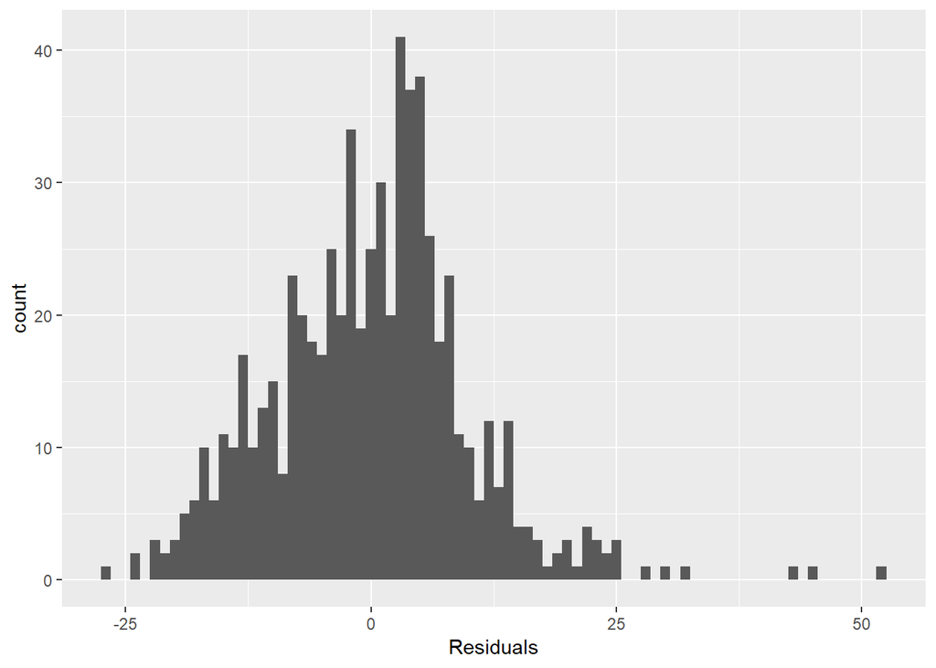

```r
ggplot(data = audscore.bayes, aes(x = .resid)) +
  geom_histogram(binwidth = 1) +
  xlab("Residuals")
```

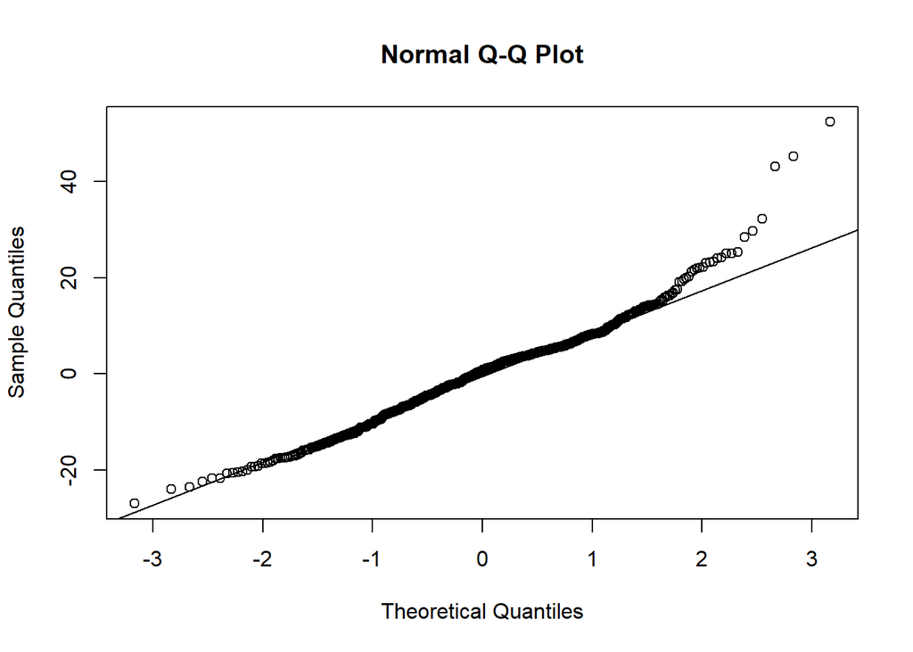

```r
qqnorm(audscore.bayes$residuals)
qqline(audscore.bayes$residuals)
```

The residuals are a bit right-skewed, and the skewedness is not that strong

Constant variability : (Residuals vs Fitted values)

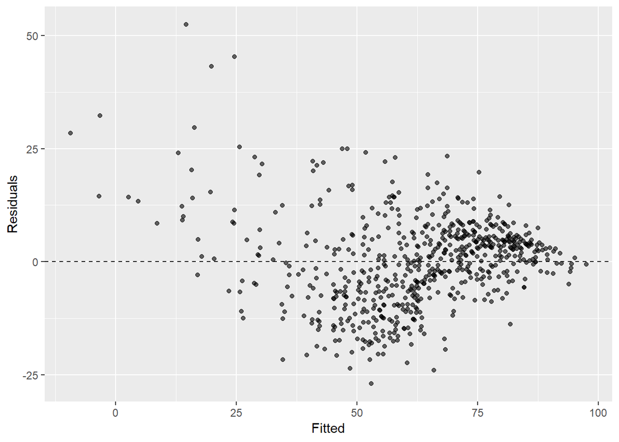

```r
ggplot(data = audscore.bayes, aes(x = .fitted, y =.resid) ) +
  geom_point(alpha = 0.6) +
  geom_hline(yintercept = 0, linetype = "dashed") +
  labs(x = "Fitted", y = "Residuals")
```

The variability of the residuals around the line seem to decrease with larger values of fitted values.

We can view absolute value of residuals vs. predicted to identify unusual observations easily

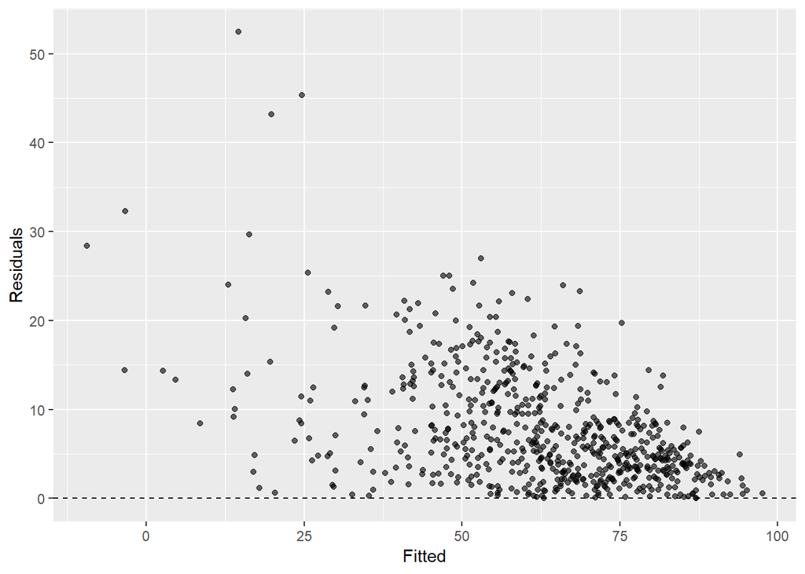

```r
ggplot(data = audscore.bayes, aes(x = .fitted, y =abs(.resid) )) +
  geom_point(alpha = 0.6) +
  geom_hline(yintercept = 0, linetype = "dashed") +
  labs(x = "Fitted", y = "Residuals")
```

There is a triangle shape in the plot, so we may not be able to ensure the constant variability of residuals.

checking for outliers

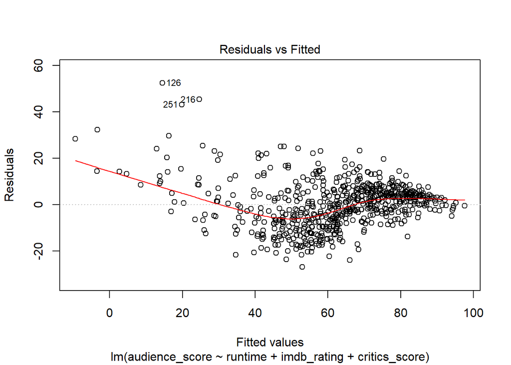

```r
plot(audscore.bayes,which=1)
```

It appears that there may be some outliers in the data - observations 126, 216 and 251 have been flagged as the points with the three largest absolute residuals. We declared observations to be outliers with respect to the population model if their deviation or error was more than k=3 standard deviations above or below 0.

```r
#checking for the probabilities of outliers using BAS package

outliers <-Bayes.outlier(audscore.bayes,k=3)


#Storing the results in a data frame
outliers_df <- data.frame(probability = outliers$prob.outlier,
                          case = 1:length(outliers$prob.outlier))

outliers_df %>%
  filter(case %in% c(126,216,251))
```

```
##   probability case
## 1 5.02433e-05  126
## 2 5.02433e-05  216
## 3 5.02433e-05  251
```

The probabilities of these cases being an outlier come out to be negligible.

We now turn to the interpretation of model coefficients.

As stated before, under the reference prior, point estimates and Bayesian credible intervals are numeriacally equivalent to frequentist estimates and confidence intervals. We can use standard lm functions to obtain them.

```r
#Extracting coeffients and their credible intervals and binding them with column names

coef<-summary(audscore.bayes)$coef[,1:2]

out=cbind(coef,confint(audscore.bayes))

colnames(out)=c("posterior mean","posterior std","2.5","97.5")

round(out,2)
```

```
##               posterior mean posterior std    2.5   97.5
## (Intercept)           -33.28          3.22 -39.60 -26.96
## runtime                -0.05          0.02  -0.09  -0.01
## imdb_rating            14.98          0.58  13.85  16.11
## critics_score           0.07          0.02   0.03   0.11
```

## Part 5: Prediction

```r
#Build test data cases for the movie “La La Land (2016)” using the data gathered from the rotten tomatoes website and storing the data in the variable

runtime=128
critics_score=86.4
imdb_rating=8.0

LaLaland<-data.frame(runtime,imdb_rating,critics_score)
```

```r
#Forming prediction intervals

predict.LaLa=predict(audscore.bayes,newdata=LaLaland,interval="prediction")
colnames(predict.LaLa)=c("prediction","lower","upper")
predict.LaLa
```

```
##   prediction    lower    upper
## 1   85.77898 66.00866 105.5493
```

https://www.imdb.com/title/tt3783958/,

https://www.rottentomatoes.com/m/la_la_land

## Part 6: Conclusion

I expected the new variables to explain the variability in audience_score because in the EDA section, they, especially ‘feature film’ and ‘drama’, seem to have significant effects on audience_score. However, all of them are excluded in the final model. Even their posterior inclusion probabilities turned out to be very low, most of them ranging from 4 to 8 % and ‘mpaa_ratingR’ having the hightest 20%. This may be partly due to the fact that the Bayesian model selection criteria are more conservative in accepting predictors than methods based on R squares , p-values and even AIC. Also, non-feature type movies, although having a much higher average audience score, account for a tiny 9.22% of the sample so their effects on the model should be relatively small. I think a very important measure of popularity of a movie is the number of votes it gets on movie ratings sites because the voting and rating are voluntary. Some movies, for example most documentaries, have very high audience scores and critics scores, but the number of votes used for the scores tend to be much lower than other popular moives. Thus, It would be better to weight audience score with numbers of votes,creating a new measure of popularity, and predict the new variale with the rest of variables. In addition, the critics_score and imdb_rating variables used in the final model have a correlation coeffient of 0.765, so we need to be aware of the possibility of the multicollinearity effects.